# practical_exercise_7, Methods 3, 2021, autumn semester

GR5: Mina Almasi, Daniel Blumenkranz, Anton Drasbæk Schiønning, Matilde Sterup

17/11/21

# Setup

```r
library(reticulate)
```

```python
import numpy as np
import matplotlib.pyplot as plt
import matplotlib.patches as mpatches
import pandas as pd
```

# Exercises and objectives

1. Estimate bias and variance based on a true underlying function
2. Fitting training data and applying it to test sets with and without regularization

For each question and sub-question, please indicate one of the three following answers:  
i. I understood what was required of me  
ii. I understood what was required of me, but I did not know how to fullfil the requirement  
iii. I did not understand what was required of me

# EXERCISE 1 - Estimate bias and variance based on a true underlying function

We can express regression as $y = f(x) + \epsilon$ with $E[\epsilon] = 0$ and $var(\epsilon) = \sigma^2$ ($E$ means expected value)

For a given point: $x_0$, we can decompose the expected prediction error , $E[(y_0 - \hat{f}(x_0))^2]$ into three parts - **bias**, **variance** and **irreducible error** (the first two together are the **reducible error**):

The expected prediction error is, which we also call the **Mean Squared Error**:  
$E[(y_0 - \hat{f}(x_0))^2] = bias(\hat{f}(x_0))^2 + var(\hat{f}(x_0)) + \sigma^2$

where **bias** is;

$bias(\hat{f}(x_0)) = E[\hat{f}(x_0)] - f(x_0)$

#### 1) Create a function, $f(x)$ that squares its input. This is our **true** function

##### i. generate data, $y$, based on an input range of [0, 6] with a spacing of 0.1. Call this $x$

```python
#True function
def squared(x):
  return(x**2)

#generate data
x = np.arange(0,6.1,0.1)
print(x)
```

```
## [0.  0.1 0.2 0.3 0.4 0.5 0.6 0.7 0.8 0.9 1.  1.1 1.2 1.3 1.4 1.5 1.6 1.7
##  1.8 1.9 2.  2.1 2.2 2.3 2.4 2.5 2.6 2.7 2.8 2.9 3.  3.1 3.2 3.3 3.4 3.5
##  3.6 3.7 3.8 3.9 4.  4.1 4.2 4.3 4.4 4.5 4.6 4.7 4.8 4.9 5.  5.1 5.2 5.3
##  5.4 5.5 5.6 5.7 5.8 5.9 6. ]
```

```python
y_true = squared(x)
print(y_true)
```

```
## [0.000e+00 1.000e-02 4.000e-02 9.000e-02 1.600e-01 2.500e-01 3.600e-01
##  4.900e-01 6.400e-01 8.100e-01 1.000e+00 1.210e+00 1.440e+00 1.690e+00
##  1.960e+00 2.250e+00 2.560e+00 2.890e+00 3.240e+00 3.610e+00 4.000e+00
##  4.410e+00 4.840e+00 5.290e+00 5.760e+00 6.250e+00 6.760e+00 7.290e+00
##  7.840e+00 8.410e+00 9.000e+00 9.610e+00 1.024e+01 1.089e+01 1.156e+01
##  1.225e+01 1.296e+01 1.369e+01 1.444e+01 1.521e+01 1.600e+01 1.681e+01
##  1.764e+01 1.849e+01 1.936e+01 2.025e+01 2.116e+01 2.209e+01 2.304e+01
##  2.401e+01 2.500e+01 2.601e+01 2.704e+01 2.809e+01 2.916e+01 3.025e+01
##  3.136e+01 3.249e+01 3.364e+01 3.481e+01 3.600e+01]
```

##### ii. add normally distributed noise to $y$ with $\sigma=5$ (set a seed to 7 `np.random.seed(7)`) to $y$ and call it $y_{noisy}$

```python
np.random.seed(7)
sigma = 5

y_noise = y_true + np.random.normal(loc = 0, scale = sigma, size = len(y_true))
```

##### iii. plot the true function and the generated points

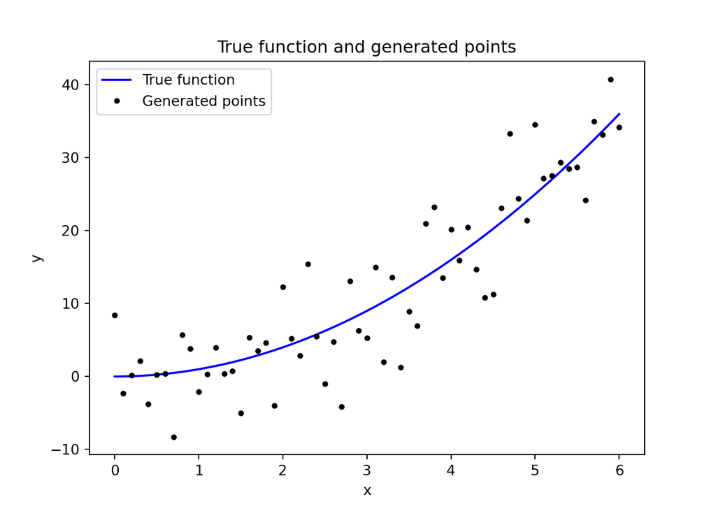

```python
plt.figure() # create new figure
plt.plot(x, y_true, 'b-') # plot the true function
plt.plot(x,y_noise, 'k.') # generated points
plt.xlabel('x')
plt.ylabel('y')
plt.title('True function and generated points')
plt.legend(['True function', 'Generated points'])
plt.show()
```

#### 2) Fit a linear regression using `LinearRegression` from `sklearn.linear_model` based on $y_{noisy}$ and $x$ (see code chunk below associated with Exercise 1.2)

```python
from sklearn.linear_model import LinearRegression
regressor = LinearRegression()

x_reshape = x.reshape(-1,1) #as a column
fit = regressor.fit(x_reshape,y_noise)
```

##### i. plot the fitted line (see the `.intercept_` and `.coef_` attributes of the `regressor` object) on top of the plot (from 1.1.iii)

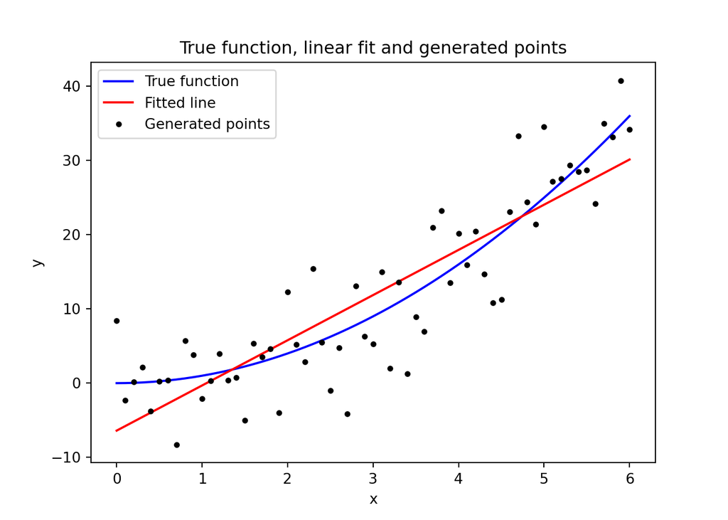

```python
intercept = fit.intercept_
slope = fit.coef_

plt.figure() # create new figure
plt.plot(x, y_true, 'b-') # plot the true function
plt.plot(x, slope*x+intercept, 'r-')
plt.plot(x,y_noise, 'k.') # generated points
plt.xlabel('x')
plt.ylabel('y')
plt.title('True function, linear fit and generated points')
plt.legend(['True function', 'Fitted line', 'Generated points'])
plt.show()
```

##### ii. now run the code chunk below associated with Exercise 1.2.ii - what does X_quadratic amount to?

```python
from sklearn.preprocessing import PolynomialFeatures
quadratic = PolynomialFeatures(degree=2)
X_quadratic = quadratic.fit_transform(x.reshape(-1, 1))
#X_quadratic is the design matrix from before but with a third column that expresses x squared
```

```python
regressor = LinearRegression()
fit_q = regressor.fit(X_quadratic, y_noise) #quadratic fit
#predicted values
y_quad_fit = regressor.predict(X_quadratic)
```

#### iii. do a quadratic and a fifth order fit as well and plot them (on top of the plot from 1.2.i)

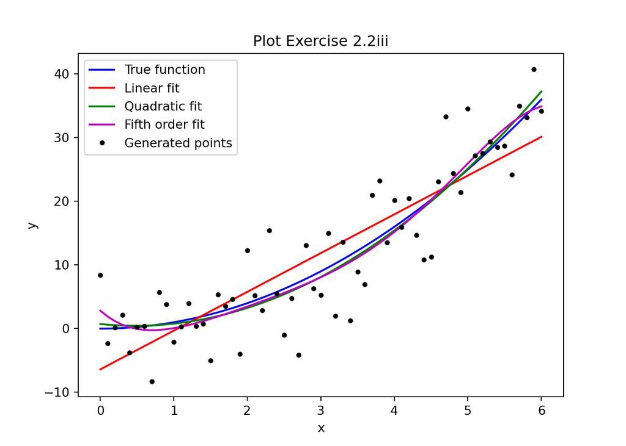

```python
fifth_order = PolynomialFeatures(degree=5)
X_fifth_order = fifth_order.fit_transform(x.reshape(-1, 1))
regressor = LinearRegression()
fit_fifth = regressor.fit(X_fifth_order, y_noise) #fifth order fit
#predicted values
y_fit_fifth = regressor.predict(X_fifth_order)


#Plot
plt.figure() # create new figure
plt.plot(x, y_true, 'b-') # plot the true function
plt.plot(x, slope*x+intercept, 'r-') #linear fit
plt.plot(x, y_quad_fit, 'g-') #quadratic fit
plt.plot(x, y_fit_fifth, 'm-') #fifth order fit
plt.plot(x,y_noise, 'k.') # generated points
plt.xlabel('x')
plt.ylabel('y')
plt.title('Plot Exercise 2.2iii')
plt.legend(['True function', 'Linear fit', 'Quadratic fit', 'Fifth order fit', 'Generated points'])
plt.show()
```

#### 3) Simulate 100 samples, each with sample size `len(x)` with $\sigma=5$ normally distributed noise added on top of the true function (iii)

```python
samples = [y_true + np.random.normal(loc = 0, scale = 5, size = len(y_true)) for i in range(100)]
```

##### i. do linear, quadratic and fifth-order fits for each of the 100 samples

```python
#Linear Fits
linear_fits = []
linear_predict = []

for y in samples:
  regressor = LinearRegression()
  linear_fits.append(regressor.fit(x_reshape, y))
  linear_predict.append(regressor.predict(x_reshape))

#Quadratic Fits
quadratic = PolynomialFeatures(degree=2)
X_quadratic = quadratic.fit_transform(x.reshape(-1, 1))

quadratic_fits = []
quadratic_predict = []

for y in samples:
  regressor = LinearRegression()
  quadratic_fits.append(regressor.fit(X_quadratic, y))
  quadratic_predict.append(regressor.predict(X_quadratic))

#Fifth-order fits
fifth_order = PolynomialFeatures(degree=5)
X_fifth_order = fifth_order.fit_transform(x.reshape(-1, 1))

fifth_fits = []
fifth_predict = []

for y in samples:
  regressor = LinearRegression()
  fifth_fits.append(regressor.fit(X_fifth_order, y))
  fifth_predict.append(regressor.predict(X_fifth_order))
```

##### ii. create a **new** figure, `plt.figure`, and plot the linear and the quadratic fits (colour them appropriately); highlight the true value for $x_0=3$. From the graphics alone, judge which fit has the highest bias and which has the highest variance for $x_0$

```python
plt.figure() # create new figure
[plt.plot(x, y, 'r-', alpha = 0.1) for y in linear_predict]
```

[output not shown]

```python
[plt.plot(x, y, 'g-', alpha = 0.1) for y in quadratic_predict]
```

[output not shown]

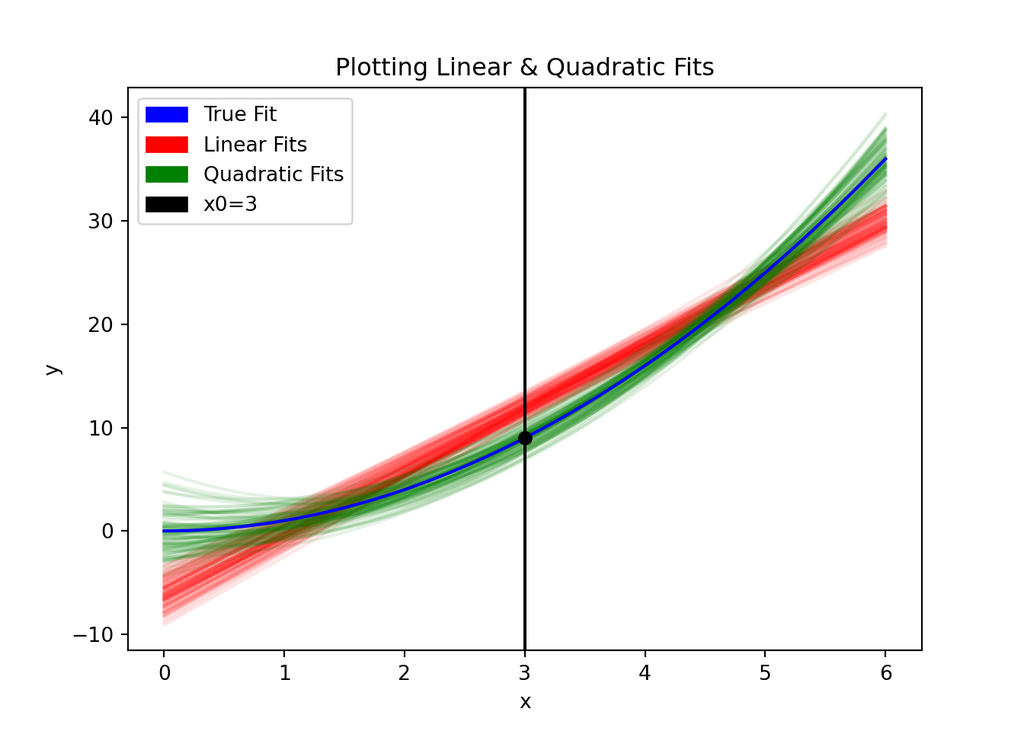

```python
plt.plot(x, y_true, 'b-') # plot the true function
plt.axvline(x = 3, color = "black")
plt.plot(3,9, 'ko')
plt.xlabel('x')
plt.ylabel('y')

true = mpatches.Patch(color='blue', label='True Fit')
linear = mpatches.Patch(color='red', label='Linear Fits')
quadratic = mpatches.Patch(color='green', label='Quadratic Fits')
x0 = mpatches.Patch(color='black', label='x0=3')

plt.title('Plotting Linear & Quadratic Fits')
plt.legend(handles=[true, linear, quadratic, x0])
plt.show()
```

Judging from the plot alone, the linear fits seem to not have as much variance as the quadratic fits. However, the linear fits are further away from the true function, indicating more bias than the quadratic fits.

##### iii. create a **new** figure, `plt.figure`, and plot the quadratic and the fifth-order fits (colour them appropriately); highlight the true value for $x_0=3$. From the graphics alone, judge which fit has the highest bias and which has the highest variance for $x_0$

```python
plt.figure() # create new figure
[plt.plot(x, y, 'm-', alpha = 0.3) for y in fifth_predict]
```

[output not shown]

```python
[plt.plot(x, y, 'g-', alpha = 0.2) for y in quadratic_predict]
```

[output not shown]

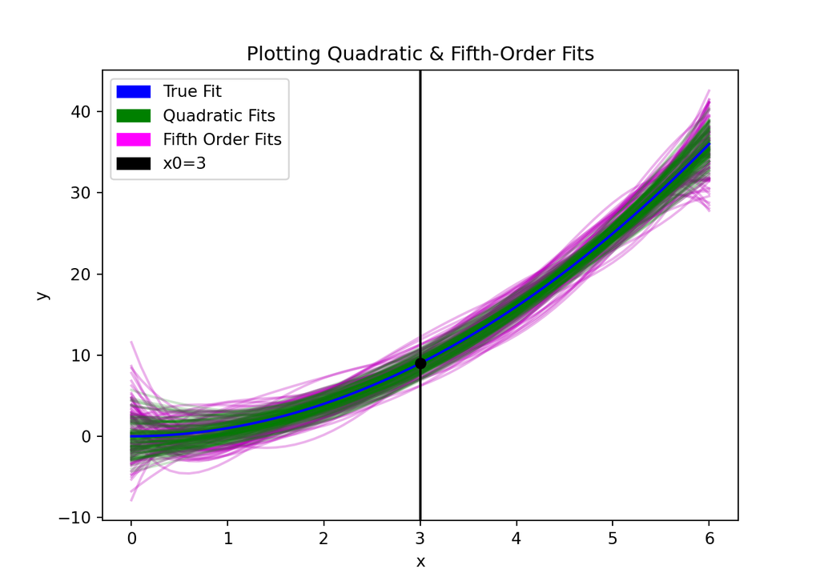

```python
plt.plot(x, y_true, 'b-') # plot the true function
plt.axvline(x = 3, color = "black")
plt.plot(3,9, 'ko')
plt.xlabel('x')
plt.ylabel('y')

true = mpatches.Patch(color='blue', label='True Fit')
quadratic = mpatches.Patch(color='green', label='Quadratic Fits')
fifth = mpatches.Patch(color='magenta', label='Fifth Order Fits')
x0 = mpatches.Patch(color='black', label='x0=3')

plt.title('Plotting Quadratic & Fifth-Order Fits')
plt.legend(handles=[true, quadratic, fifth, x0])
plt.show()
```

The two types of fits seem to be quite similar although the fifth order fits seem to have more variance. This makes sense considering the added complexity of the fifth order fits increases chances of overfitting to the data.

##### iv. estimate the **bias** and **variance** at $x_0$ for the linear, the quadratic and the fifth-order fits (the expected value $E[\hat{f}(x_0)] - f(x_0)$ is found by taking the mean of all the simulated, $\hat{f}(x_0)$, differences) (ii)

We calculate the **bias**: $bias(\hat{f}(x_0)) = E[\hat{f}(x_0)] - f(x_0)$

```python
## CALCULATING THE BIAS ##
y_true[30] # The true value for x0 = 3 is 9. Here we show that this value is number 30 in the array of y-values.
```

```
## 9.0
```

```python
fittedx03_linear = [linear_predict[i][30] for i in range(len(linear_predict))]
fittedx03_quadratic = [quadratic_predict[i][30] for i in range(len(quadratic_predict))]
fittedx03_fifth = [fifth_predict[i][30] for i in range(len(fifth_predict))]

bias_linear = np.mean(fittedx03_linear) - 9
bias_quadratic = np.mean(fittedx03_quadratic) - 9
bias_fifth = np.mean(fittedx03_fifth) - 9

bias = np.array([bias_linear, bias_quadratic, bias_fifth])
bias

## CALCULATING THE VARIANCE ##
```

```
## array([ 2.99651848, -0.08501802, -0.05436408])
```

```python
var_linear = np.var(fittedx03_linear)
var_quadratic = np.var(fittedx03_quadratic)
var_fifth = np.var(fittedx03_fifth)

variance = np.array([var_linear, var_quadratic, var_fifth])
variance
```

```
## array([0.42392992, 0.81654802, 1.29946564])
```

##### v. show how the **squared bias** and the **variance** is related to the complexity of the fitted models

```python
## CALCULATING THE SQUARED BIAS ##
squared_bias_linear = squared(bias_linear)
squared_bias_quadratic = squared(bias_quadratic)
squared_bias_fifth = squared(bias_fifth)

squared_bias = np.array([squared_bias_linear, squared_bias_quadratic, squared_bias_fifth])
squared_bias

## VISUALISING ##
```

```
## array([8.97912300e+00, 7.22806435e-03, 2.95545283e-03])
```

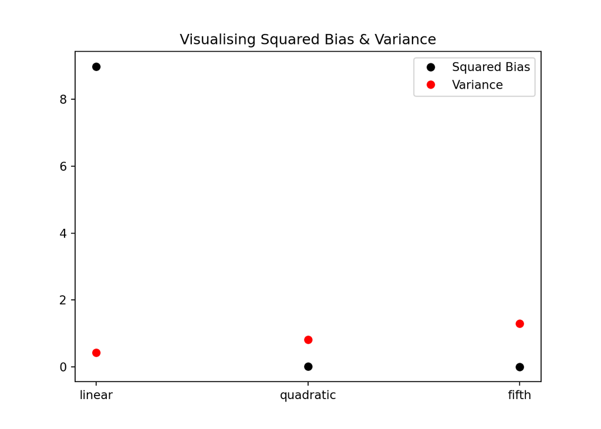

```python
plt.figure()
plt.plot(["linear", "quadratic", "fifth"], squared_bias, "ko")
plt.plot(["linear", "quadratic", "fifth"], variance, "ro")
plt.legend(["Squared Bias", "Variance"])
plt.title("Visualising Squared Bias & Variance")
plt.show()
```

As predicted from the plot made in 1.3ii, the linear fit has the highest bias but lowest variance. The fifth order plots has the lowest bias, but also the highest variance. This illustrates the bias-variance trade-off.